# Tutorial for Session 3 Climate change sentiment in UN General Assembly Speeches

## Climate-change related sentiment over time

Now we can finally have a look at the sentiment that national delegates attach to climate change when they speak in the UNGA. Again we use `ggplot` to plot the sentiment data we have derived above. Let’s start with the pattern over time (years, to be specific).

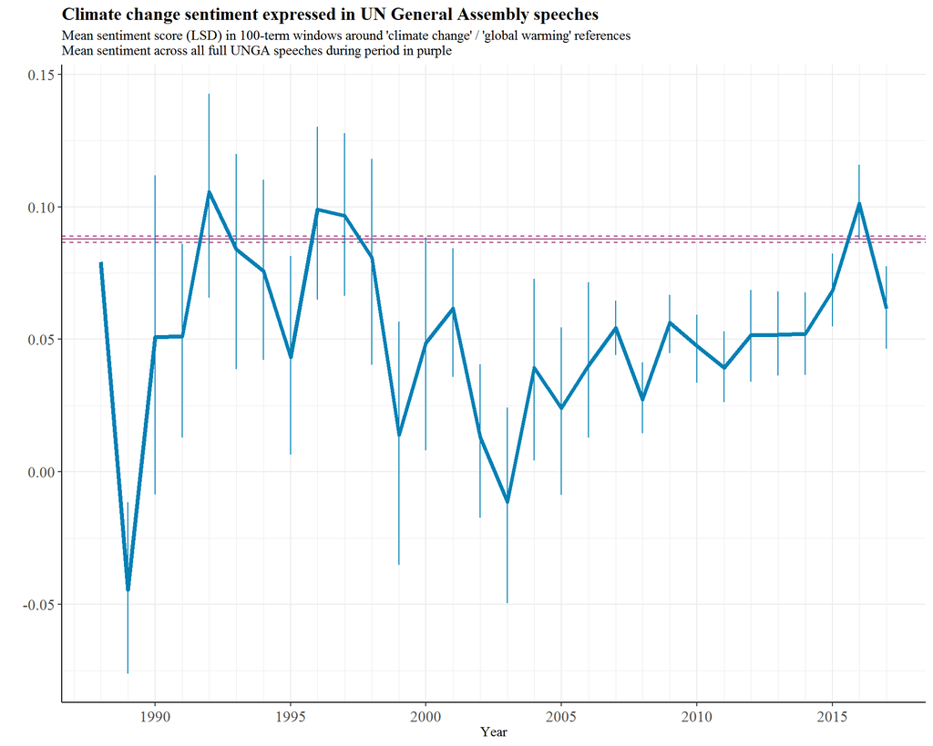

```r
ggplot(data = climate2, aes(x = year, y = sent))+
  geom_hline(yintercept = average.sentiment.upper, linetype = "dashed", color = "#9e3173", size = .5)+ # Upper confidence bound
  geom_hline(yintercept = average.sentiment.lower, linetype = "dashed", color = "#9e3173", size = .5)+ # lower cofidence bound
  geom_hline(yintercept = average.sentiment, color = "#9e3173")+ # Mean confidence in full speeches
  stat_summary(geom = "linerange", fun.data = "mean_cl_boot", color = "#0380b5", size = .5) + # Confidence bounds of sentiment in climate change texts
  stat_summary(geom = "line", fun.y = "mean", color = "#0380b5", size = 1.5) + # Mean sentiment in climate change texts
  scale_x_continuous(breaks = seq(1970, 2015, 5), minor_breaks = seq(1970, 2017, 1))+
  labs(title = "Climate change sentiment expressed in UN General Assembly speeches",
       subtitle = "Mean sentiment score (LSD) in 100-term windows around 'climate change' / 'global warming' references\nMean sentiment across all full UNGA speeches during period in purple",
       x = "Year",
       y = "")+
  theme_bw()+
  theme(axis.text.x = element_text(angle = 0, vjust = .5, size = 12),
        axis.text.y = element_text(size = 12),
        text=element_text(family = "serif"),
        panel.border = element_blank(),
        axis.line = element_line(colour = "black"),
        plot.title = element_text(size=14, face='bold'),
        plot.caption = element_text(size=14))
```

```r
ggsave(file = "PL_SentimentOverTime.png", width = 18, height = 12, units = "cm")
```

## Climate-change related sentiment by country

Speaking about climate bargains, we also want to know what sentiment individual states associate with references to climate change in UNGA speeches. Let `ggplot` aggregate the retrieved sentiment values along those lines:

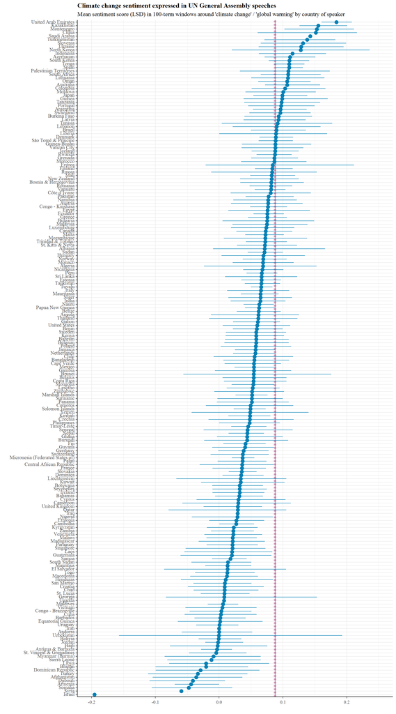

```r
ggplot(data = climate2, aes(x = reorder(country, sent, mean), y = sent))+
  geom_hline(yintercept = average.sentiment.upper, linetype = "dashed", color = "#9e3173", size = .5)+ # Upper confidence bound
  geom_hline(yintercept = average.sentiment.lower, linetype = "dashed", color = "#9e3173", size = .5)+ # lower cofidence bound
  geom_hline(yintercept = average.sentiment, color = "#9e3173")+ # Mean confidence in full speeches
  stat_summary(geom = "pointrange", fun.data = "mean_cl_boot", color = "#0380b5", size = .5) +
  stat_summary(geom = "point", fun.y = "mean", color = "#0380b5", size = 3) +
  labs(title = "Climate change sentiment expressed in UN General Assembly speeches",
       subtitle = "Mean sentiment score (LSD) in 100-term windows around 'climate change' / 'global warming' by country of speaker",
       x = "",
       y = "")+
  coord_flip(ylim = c(-0.2, 0.25))+
  theme_bw()+
  theme(axis.text.x = element_text(angle = 0, vjust = .5),
        text=element_text(family = "serif"),
        panel.border = element_blank(),
        axis.line = element_line(colour = "black"),
        plot.title =element_text(size=12, face='bold'),
        axis.text.y = element_text(size = 9, vjust = .3))
```

```r
ggsave(file = "PL_SentimentAcrossAllCountries.png", width = 17, height = 26, units = "cm")
```

This is arguably too much for a single plot. But this aggregate perspective reveals some interesting information about climate-change related sentiment in UNGA speeches:

- There is quite some variation in the mean sentiment around climate change refernces across individual countries
- Yet, there is also quite some variation ‘within’ indivdual countries and across time (seeUzbekistan or Georgia, e.g.)
- Despite this variation within countries, some states express climate-change related sentiment that is consistently more positive/negative than the mean of all UNGA speeches. The United Arab Emirates, China, or Saudi Arabia use rather postive language when refering to climate change. Other countries, like Djibouti, Sierra Leone, St. Vincent & Grenadines, or Haiti, for example, use much more negative language when referring to climate change.

As noted above, whether we can interpret this as expressed positions towards climate change (or its mitigation?) depends on how well our 100-term window actually captures speech segments that primarily adresses climate change. This assumption can be checked, of course, by qualitatively assessing *samples from these text bits*. Let’s have a look at Israel which is the most negative outlier in our data but has referred to climate change only once in the period we cover.

```r
climate2$text[climate2$country == "Israel"]
```

```
## [1] " is not just a problem for my country , it is a problem for the other countries too . If the United Nations spends so much time condemning the only liberal democracy in the Middle East , it has far less time to address war , disease , poverty , and all of the other serious problems that plag…
```

Note that we have removed the climate change reference itself earlier (see the second code-chunk above). But in this example it was most likely in the list with ‘war’, ‘disease’, and ‘poverty’ that the Israeli representative refers to. This example, however, was apparently not primarily about climate change but rather about security concerns.  
Still the observation hat climate change was mentioned in a very negative context is correct. But with regard to interpreting this as a climate change position right away, caution is warranted. The sentiment measure is at least ‘noisy’ in this regard. Let’s look at an example of the outlier with the most positive laguage around climate change references, the United Arab Emirates.

```r
climate2$text[climate2$country == "United Arab Emirates"][1]
```

```
## [1] " meantime , we welcome the positive results of the West Point conference on combating terrorism , and look forward to the success of the next conference , to be held in the Republic of Korea . As part of our efforts to strengthen international cooperation in addressing the challenges of , an…
```

This exemplary text also starts from security topics, but is by and large about climate change, calling for (future) support of island states in particular by using very positively connoted language. This can be plausibly interpreted as a positive stance towards climate change mitigation (!). Yet, in sum, these two examples suggest that further validation would be necessary here … Go ahead!

## Climate-change related sentiment by country - a crude model

Checking whether our sentiment scores are plausibly related to external, climate-change data provides another hint as to whether they are a good measure for (expressed) climate change positions. To this end, we exploit the `cmeans` data already used in the first Tutorial to see whether the average climate-change sentiment is statistically affected by aggregated economic, political, and geographic indicators. We aggregate the data frame with the sentiment scores (`climate2`), merge it with `cmeans` by the iso country code variable, then run a simple linear regression (crude!) and interpret it visually with the help of the `coeffplot` and `ggplot` packages (see Tutorial 1 for comments on the individual steps).

```r
countries <- aggregate(sent ~ country+iso3c, data = climate2, FUN = "mean") # Mean sentiment score by country
load("cmeans.Rdata") # Country data 1987-2017 averages, collected from World Bank, Wikipedia, Polity, and Freedom House (crude!)
countries <- merge(countries, cmeans, by = "iso3c", all.x = T) # merge with the aggregated sentiment data
countries <- countries[complete.cases(countries), ] # Keep only countries with information on all variables

# Regression model
fit <- lm(scale(sent)~scale(gdpc) + scale(co2emiss) + scale(fuel.exp) + scale(democracy) + scale(eq.dist) + scale(below5) + scale(island), data = countries)
summary(fit)
```

```
##
## Call:
## lm(formula = scale(sent) ~ scale(gdpc) + scale(co2emiss) + scale(fuel.exp) +
##     scale(democracy) + scale(eq.dist) + scale(below5) + scale(island),
##     data = countries)
##
## Residuals:
##     Min      1Q  Median      3Q     Max
## -5.8182 -0.5694  0.0737  0.6113  2.6660
##
## Coefficients:
##                    Estimate Std. Error t value Pr(>|t|)
## (Intercept)      -1.856e-16  7.178e-02   0.000    1.000
## scale(gdpc)      -9.094e-02  1.533e-01  -0.593    0.554
## scale(co2emiss)   1.955e-01  1.541e-01   1.268    0.206
## scale(fuel.exp)   4.133e-02  8.791e-02   0.470    0.639
## scale(democracy)  7.827e-02  8.889e-02   0.880    0.380
## scale(eq.dist)    8.598e-02  8.772e-02   0.980    0.328
## scale(below5)    -2.661e-02  7.664e-02  -0.347    0.729
## scale(island)    -8.721e-02  8.395e-02  -1.039    0.300
##
## Residual standard error: 0.9921 on 183 degrees of freedom
## Multiple R-squared:  0.05207,    Adjusted R-squared:  0.01581
## F-statistic: 1.436 on 7 and 183 DF,  p-value: 0.1932
```

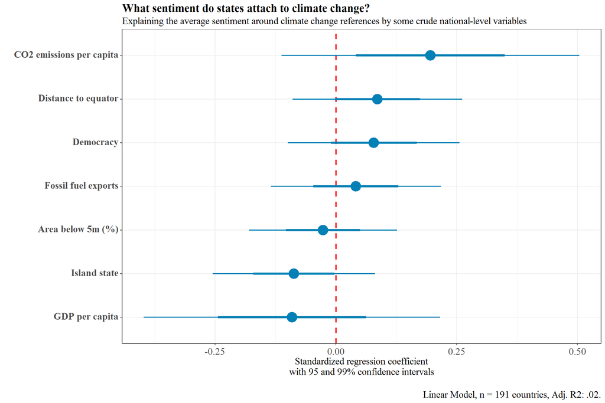

```r
# Coefficient data
reg.data <- coefplot(fit, plot = FALSE) # Get coefficient data
reg.data <- reg.data[reg.data$Coefficient != "(Intercept)", ] # Uninformative in a standardized model
reg.data$name <- c("GDP per capita", "CO2 emissions per capita", "Fossil fuel exports", "Democracy", "Distance to equator", "Area below 5m (%)", "Island state") # Human readable names
reg.data <- reg.data[order(reg.data$Value), ] # Sort in ascending effect size
reg.data$name <- factor(reg.data$name, levels = reg.data$name)

# And plot
ggplot(data = reg.data, aes(x=name, y = Value))+
  geom_hline(yintercept = 0, linetype = "dashed", colour = "red", size = 1)+
  geom_linerange(aes(ymin = LowOuter, ymax = HighOuter), size = .8, colour = "#0380b5")+
  geom_pointrange(aes(ymin = LowInner, ymax = HighInner), size = 1.5, colour = "#0380b5")+
  labs(title = "What sentiment do states attach to climate change?",
       subtitle = "Explaining the average sentiment around climate change references by some crude national-level variables",
       y = "Standardized regression coefficient\nwith 95 and 99% confidence intervals\n",
       x = "",
       caption = "Linear Model, n = 191 countries, Adj. R2: .02.")+
  coord_flip()+
  theme_bw()+
  theme(axis.text.x = element_text(size = 14, angle = 0, vjust = .5),
        axis.title = element_text(size = 14),
        axis.text.y = element_text(size = 14, face = "bold", vjust = .3),
        text=element_text(family = "serif"),
        axis.line = element_line(colour = "black"),
        plot.title =element_text(size=16, face='bold'),
        plot.subtitle = element_text(size=14),
        plot.caption = element_text(size = 14))
```

```r
ggsave(file = "PL_SentimentOverCountries_Model.png", width = 30, height = 18, units = "cm") # Export to file
```

Apparently we see … not much. The model fit is extremely low and the tendencies we see are statistically not different from zero (red line in the figure). Together with our qualitative insights on individual text bits above, this suggest that our sentiment scores in the 100-term window around climate change references (which are averaged across time here, in addition) are way too crude to capture meaningful positions.  
*Do you have ideas to sharpen the approach? How about scrutinizing more targeted references to specific climate agreements and treaties, for example? To then explain them with more theoretically guided variables that also vary over time? You now have the basic tools to conduct and test a sentiment analysis on your own.*  
But for now, lets head over to the next turorials which introduce you to different approaches to gather information about political positions from textual data.